# l11_en

Research Seminar

Week 11: Causality

Sergi Martínez

smsoler@clio.uc3m.es | Office hours: Tuesday 10:00–13:00 (by prior email)

## Today

Friday, November 20

- Experiments
  - Conjoint, lab and field experiments
- Our reality and some alternatives

## Warm-up

Survey for Friday 20

## How does a randomized trial work?

- One of the problems with this way of doing research is that we will just see associations. To identify causal associations, we need need the potential outcome framework:

**Logic**: we want $Y_i(1) - Y_i(0)$, but we only observe one of the two for each unit. Randomization makes the control group a valid stand-in for the missing counterfactual.

- Why? Because $E[Y(0) \mid D=1] = E[Y(0) \mid D=0]$ and the selection bias term is zero **in expectation**
- Therefore, exposure to our independent variable is not determined by any prior factor, **it is exogenous**, and the difference in the outcome between the `treated group` and the `control group` is caused by the `treatment`

## Flowchart

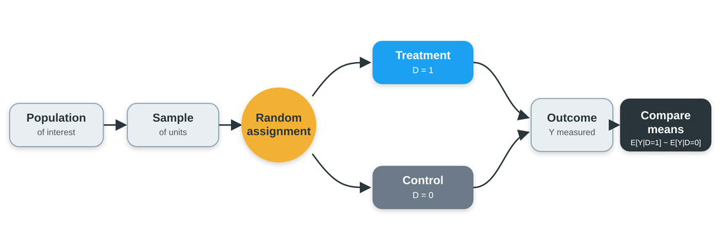

## What can go wrong in practice (when randomizing)?

| Step | Question | Typical problem |
| --- | --- | --- |
| Assignment | Was it really random? | Implementation errors, partial or manual assignment |
| Balance | Do groups look alike *before* treatment? | If imbalanced, randomization failed |
| Compliance | Did assigned people receive the treatment? | **Noncompliance**: ITT $\neq$ effect of treatment received |
| Interference | Does my treatment affect your outcome? | **Spillovers** violate SUTVA (households, neighbours, villages) |
| Attrition | Do we observe everyone’s outcome? | Differential loss of units across arms |
| Inference | At which level was treatment assigned? | Cluster the standard errors at that level |
| **Ethics** | Who bears the costs and risks? | Consent, harm, deception |

We will focus on the **ATE**, but:

- **ITT** (intention to treat): compare by *assignment*

## Types of experiments

- Survey experiments~
  - Conjoint experiments
- Lab experiments
- Field experiments

## Conjoint (from sets of attributes): If you let me choose…

**Description**:

- Each person is shown profiles (events, candidacies, products, policies) made up of several attributes.
- The **levels of each attribute are assigned at random**, so that no attribute is correlated with another.
- The person chooses between profiles (better) or rates them (less good). Each participant repeats the task several times.

**Pros**:

- Estimates the **causal effect of each attribute** on the choice, thanks to randomization.
- Allows us to **compare the relative importance** of very different attributes, for example, for candidates, the policy agenda versus ethnic origin.
- Reduces social desirability bias, because people are not asked directly about the reason for their choice.

**What it is used for**:

- Marketing: consumer preferences for products with different attributes

## Classic examples in political science

- The good immigrant
- The perfect presidential candidate:

[interactive chart not shown]

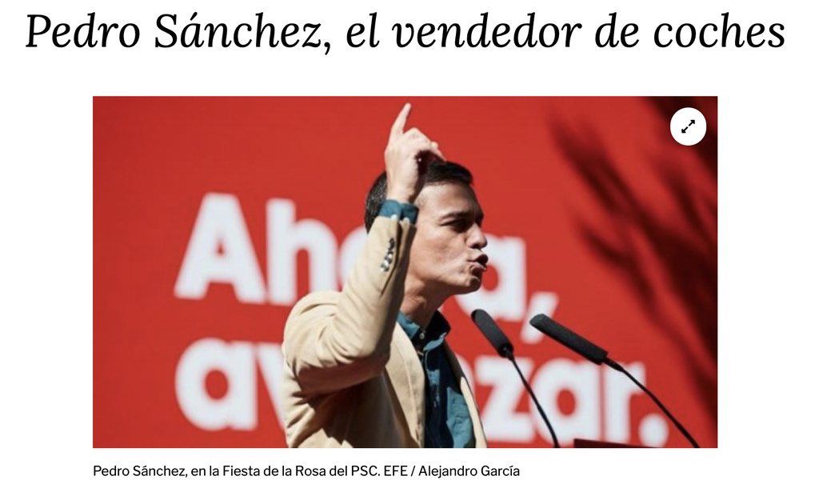

## Example: The value of democracy

*How would you measure what type of state people prefer?*

[interactive chart not shown]

## Example: The value of democracy (II)

[interactive chart not shown]

## Limitations of conjoint experiments

- Some combinations of attributes produce unrealistic profiles
- Forcing a choice usually produces inconsistencies that do not carry over to real behavior

**Lab experiments**

**Definition**: participants come to a *controlled environment* (a laboratory or classroom) where the researcher manipulates a variable, randomly assigns subjects to conditions and measures reactions immediately [remember that surveys used not to be run online]

- **What is manipulated**: a specific stimulus, such as an edited leaflet, a political message, a campaign ad or the rules of a bargaining or public goods game
- **What is measured**: attitudes, decisions or behavior during the session, sometimes with quasi-behavioral measures that do not exist in a survey (response times, eye tracking, games with real payoffs)

**Pros**

- Capture behaviors (in non-real settings)
- **Control of the environment**: same conditions, only what we manipulate changes -> **internal validity** (causality)
- **Mechanisms**: we can measure intermediate steps (attention, recall, counterarguments) and not just the final outcome
- **Treatments that do not exist in real life**: we can create the exact stimulus the theory requires and hold everything else constant
- **Moderate cost**

## Example: Milgram

[video not shown]

## Example: Baldassarri and Grossman

[interactive chart not shown]

## Example: Gilligan, Samii, Pasquale

[interactive chart not shown]

## Limitations

**Of surveys (experiments), in general, but also lab experiments**

- Surveys rarely capture real behavior, and hypothetical decisions can differ from real ones.
- Survey treatments tend to be weak and unrealistic:
  - We are exposed to thousands of messages of that kind throughout the day
  - They are far from real experiences [*low external validity*]

## Example: Barabas and Jerit

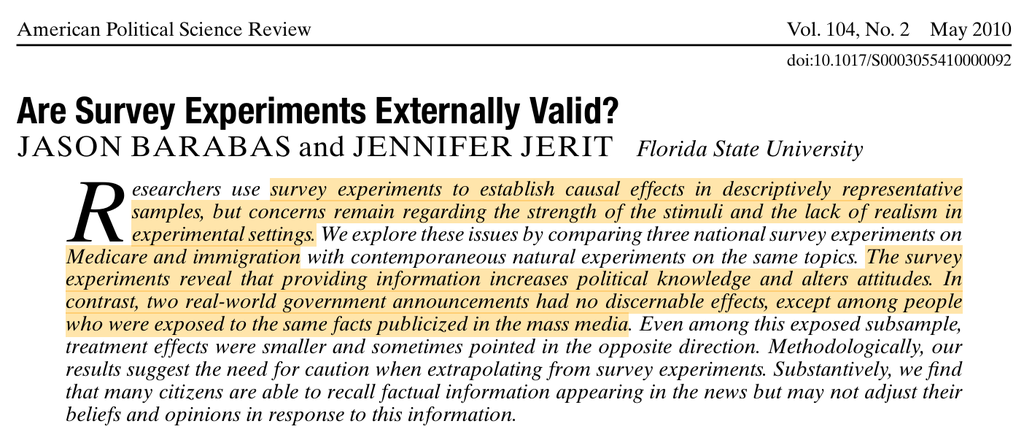

## The “solution”

The *Jabugo ham* of the social sciences: **randomized controlled field experiments**

- Among the members of a sample, we control and randomize their presence or exposure to an event, an experience, or a process that occurs in real life: *Randomization* does not happen in laboratories or surveys, but *in everyday situations*
- Common examples: canvassing or get-out-the-vote (GOTV) campaigns in elections, education experiments, public health experiments, etc.

## Field experiments (randomized controlled trials)

A method in which the researcher manipulates an independent variable (such as sending electoral information, a public policy or an incentive) in a real, everyday setting, in order to measure its causal effect on the behavior of citizens, leaders or institutions.

- Natural setting of the treatment: they take place outside the laboratory, outside of a survey, in real life.
  - Randomization: subjects or units of study (individuals, neighborhoods, polling stations) are randomly divided into a treatment group (receives the stimulus) and a control group (does not).
  - Causal inference: they isolate cause-and-effect relationships with high external validity, since they take place in real conditions.
- Outcomes/dependent variable are measured with surveys, with administrative data on behavior or decisions, etc.

## Example

[figure not shown]

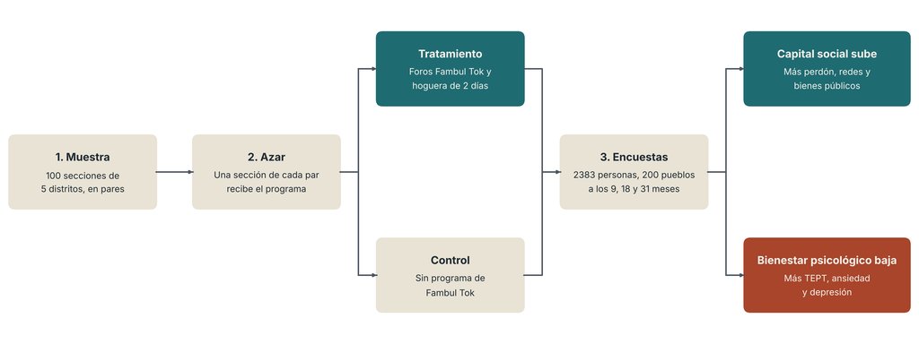

## Two examples

- Gerber and Green, GOTV
- Barceló and Vela

[figure not shown]

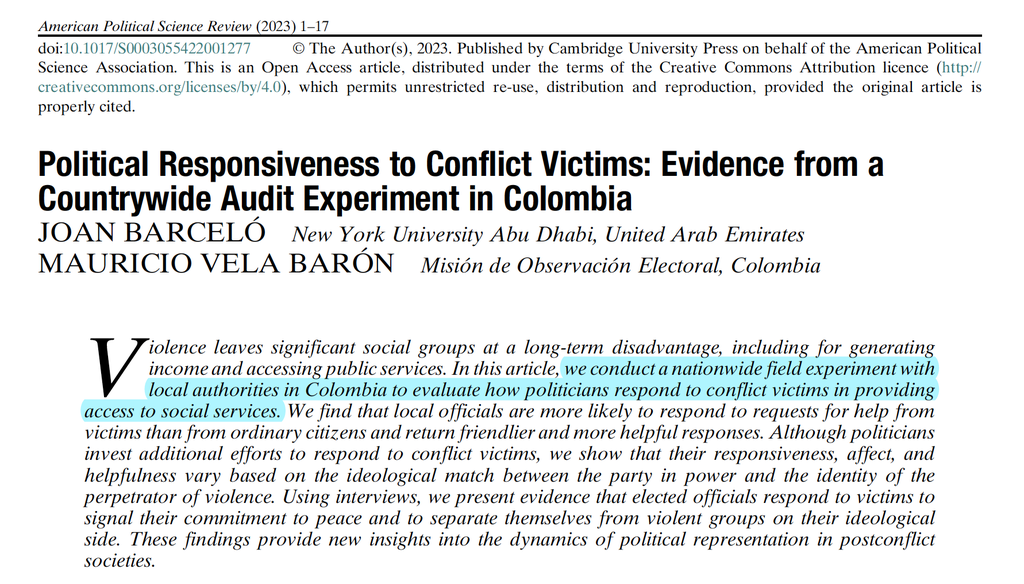

## Another one: can a course improve news discernment?

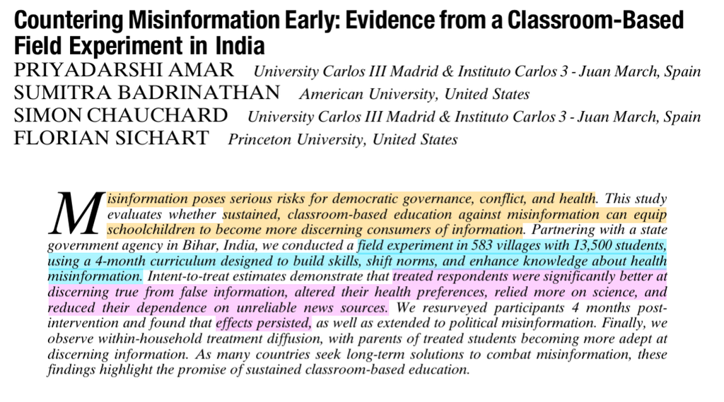

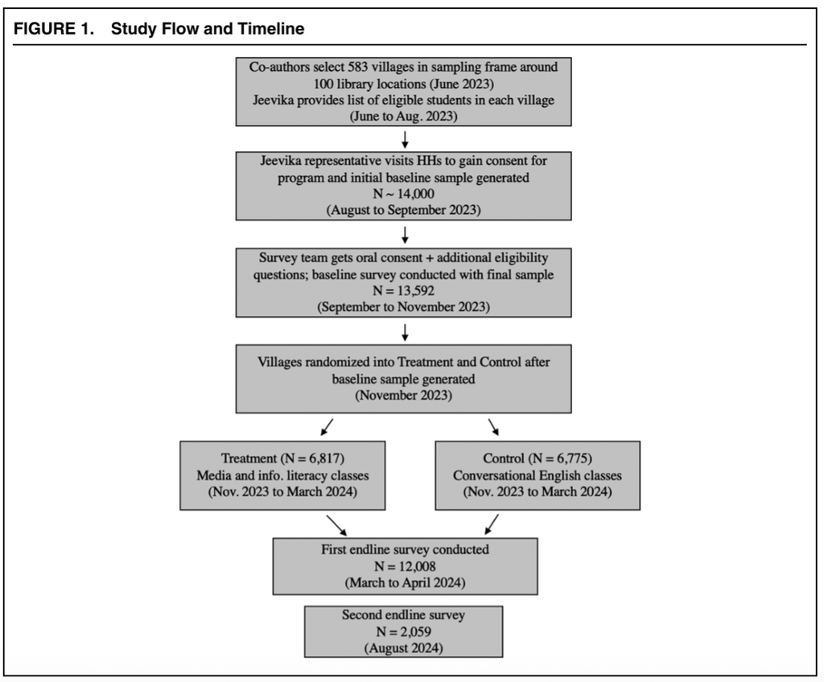

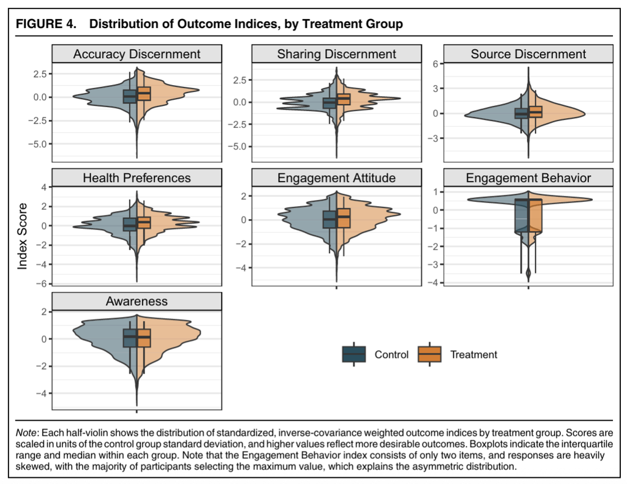

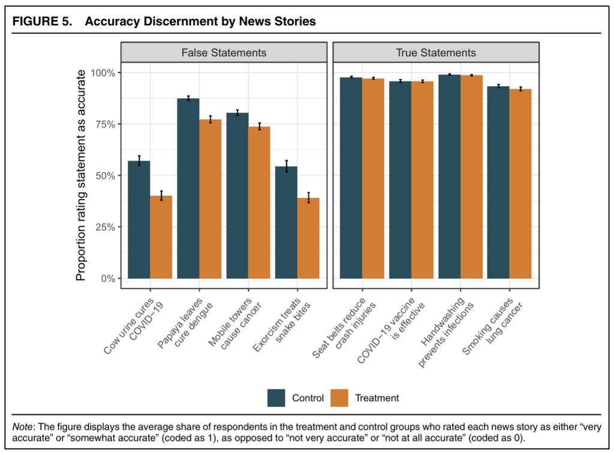

## Reminder:

By randomizing, we get rid of issues with:

1. Reverse causality: does a greater ability to tell correct from incorrect news cause people to attend the course?
- No. Why? Because they assign the treatment (randomly).
2. Omitted variables: are people more interested in politics the ones who attend the course and who also have a greater ability to tell correct from incorrect news?
- No, because they were selected at random and pre-treatment balance confirms that.

[video not shown]

## Example: Mousa (2020)

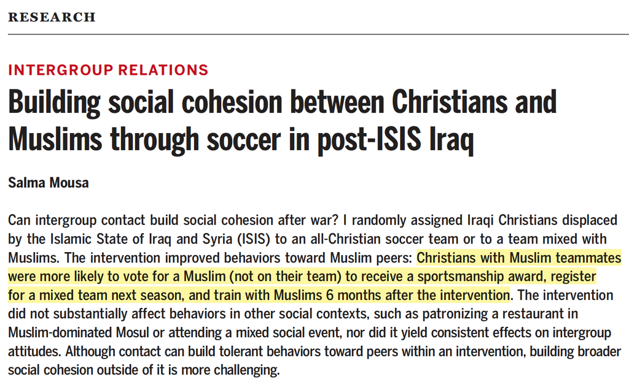

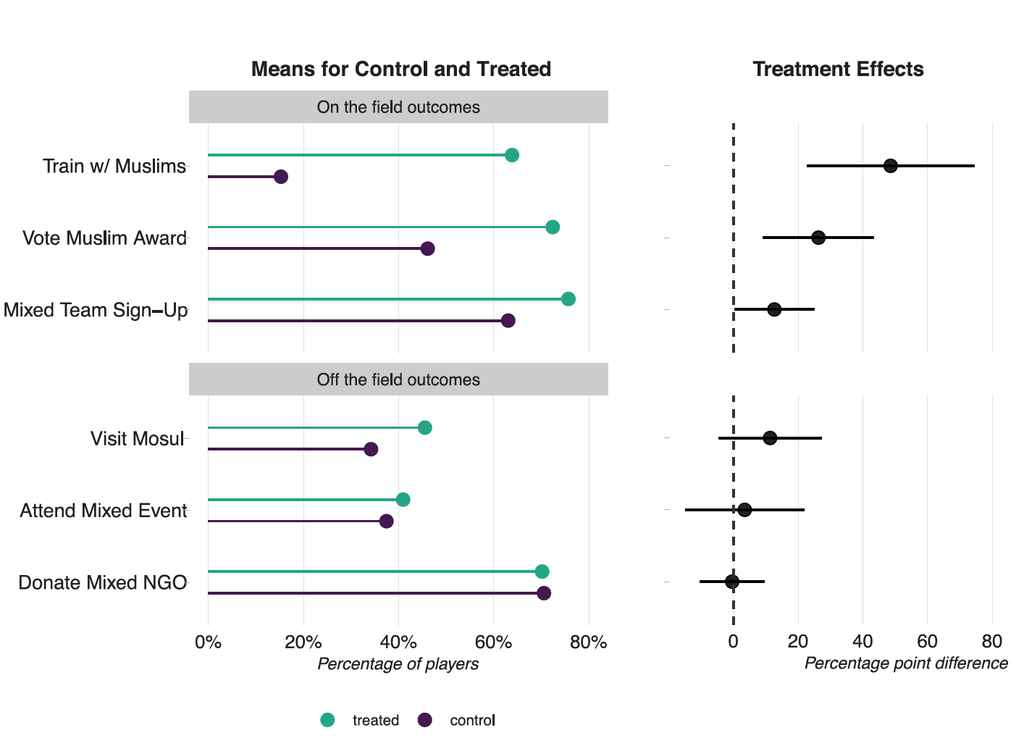

## Replication: Gerber, Green and Larimer (2008)

**Social pressure and voter turnout** (*APSR* 102(1)).

- About 300,000 Michigan registered voters (grouped in households) were randomly assigned before the August 2006 primary to one of four conditions:

| Condition | Mailing |
| --- | --- |
| Control | Nothing |
| Civic Duty | “Voting is a civic duty” |
| Hawthorne | “You are being studied” |
| Neighbors | Shows your own and your neighbors’ past turnout, and promises an update |

```r
library(sandwich); library(lmtest)

social <- read.csv("https://raw.githubusercontent.com/kosukeimai/qss/master/CAUSALITY/social.csv")
social$messages <- relevel(factor(social$messages), ref = "Control")
social$age <- 2006 - social$yearofbirth

# 1. Balance check: pre-treatment covariates should look alike across arms
aggregate(cbind(primary2004, age, hhsize) ~ messages, data = social, FUN = mean)
```

```
    messages primary2004      age   hhsize
1    Control   0.4003388 49.81355 2.183667
2 Civic Duty   0.3994453 49.65904 2.189126
3  Hawthorne   0.4032300 49.70480 2.180138
4  Neighbors   0.4066647 49.85294 2.187770
```

## Replication: balance and ITT effects

```r
# Joint F-test of balance on past turnout (should NOT reject)
summary(lm(primary2004 ~ messages, data = social))$fstatistic
```

```
       value        numdf        dendf
2.147596e+00 3.000000e+00 3.058620e+05
```

```r
# 2. ITT: difference in 2006 turnout by assigned condition
m1 <- lm(primary2006 ~ messages, data = social)
coeftest(m1, vcov = vcovHC(m1, type = "HC2"))
```

```
t test of coefficients:

                    Estimate Std. Error  t value  Pr(>|t|)
(Intercept)        0.2966383  0.0010445 283.9984 < 2.2e-16 ***
messagesCivic Duty 0.0178993  0.0025947   6.8984  5.27e-12 ***
messagesHawthorne  0.0257363  0.0026094   9.8628 < 2.2e-16 ***
messagesNeighbors  0.0813099  0.0026918  30.2071 < 2.2e-16 ***
---
Signif. codes:  0 '***' 0.001 '**' 0.01 '*' 0.05 '.' 0.1 ' ' 1
```

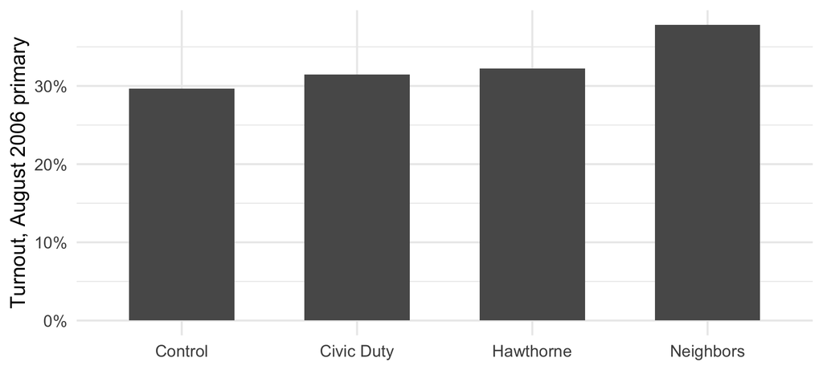

```r
means <- aggregate(primary2006 ~ messages, social, mean)
ggplot(means, aes(x = reorder(messages, primary2006), y = primary2006)) +
  geom_col(width = 0.6) +
  scale_y_continuous(labels = scales::percent) +
  labs(x = NULL, y = "Turnout, August 2006 primary") +
  theme_minimal(base_size = 18)
```

**Note**

The Neighbors mailing raises turnout by about 8 percentage points over control, far above the 1 to 3 points of the other mailings.

## Replication: heterogeneity and covariate adjustment

```r
# 3. Covariates: improve precision, should not move the estimate if randomization worked
m2 <- lm(primary2006 ~ messages + primary2004 + age + hhsize + sex, data = social)
coeftest(m2, vcov = vcovHC(m2, type = "HC2"))["messagesNeighbors", ]
```

```
     Estimate    Std. Error       t value      Pr(>|t|)
 8.024185e-02  2.627721e-03  3.053667e+01 1.730159e-204
```

```r
# 4. Heterogeneity: is the effect larger among people who voted in 2004?
m3 <- lm(primary2006 ~ messages * primary2004, data = social)
coeftest(m3, vcov = vcovHC(m3, type = "HC2"))
```

```
t test of coefficients:

                                  Estimate  Std. Error  t value  Pr(>|t|)
(Intercept)                     0.23710990  0.00125592 188.7938 < 2.2e-16 ***
messagesCivic Duty              0.01829268  0.00314060   5.8246 5.731e-09 ***
messagesHawthorne               0.02329626  0.00316626   7.3577 1.876e-13 ***
messagesNeighbors               0.06929617  0.00330968  20.9374 < 2.2e-16 ***
primary2004                     0.14869507  0.00216157  68.7904 < 2.2e-16 ***
messagesCivic Duty:primary2004 -0.00065209  0.00535957  -0.1217    0.9032
messagesHawthorne:primary2004   0.00498511  0.00537314   0.9278    0.3535
messagesNeighbors:primary2004   0.02722908  0.00548841   4.9612 7.010e-07 ***
---
Signif. codes:  0 '***' 0.001 '**' 0.01 '*' 0.05 '.' 0.1 ' ' 1
```

## Potential problems in this (and any) field experiment

- **Intention to treat only**: we know who was sent a mailing, not who opened or read it. It’s just ITT [would that over or underestimate the effect]
- **Interference-spillovers (SUTVA)**: neighbors may talk to each other, or receive different mailings [would that over or underestimate the effect]
- **Outcome measured with public records**: no attrition problem
  - The “Hawthorne” arm bundles surveillance with a reminder?
- **Interpretation of the mechanism**: social pressure works, but the design can’t separate if it’s
  - the pressure
  - the information on past turnout
  - the promise of a follow-up
- **External validity**: one state, one low-turnout primary, one year
- **Ethics**: publishing or threatening to publish people’s turnout records to their neighbors raises privacy and consent concerns, and some recipients complained
- **Multiple arms**: with four arms we make several comparisons, so report all of them and not only the strongest

## Back to discrimination: Another example

How would you measure discrimination in everyday life?

- Hint: think about a possible field experiment. What daily life situation may capture racism? discrimination?

Three groups:

- [G1](https://www.dropbox.com/scl/fi/dl5ra9qub0qvdw7we74zn/L11_G1.pdf?rlkey=4n2i59toas1yc0crps37its7c&st=oerbmvvx&dl=0)
- [G2](https://www.dropbox.com/scl/fi/72jwdoa2jn28i9rfqpiyr/L11_G2.pdf?rlkey=lb73zok3za3tzi2mjqetmpbgv&st=mpqv2590&dl=0)
- [G3](https://www.dropbox.com/scl/fi/gpbcnc2r0paer9vb7gvb4/L11_G3.pdf?rlkey=0uy8jbpqh6o7wkb1pml1x5clb&st=6nk8w100&dl=0)

Each group reads its part and we discuss it critically together:

1. Summary of that part (2-3’)
2. What questions do you have about that part, what is missing and what do you think makes no sense (1-2’)
3. Let’s discuss the limitations and risks of this article

## Assumptions

- ITT?
- SUTVA?
- Mechanisms?
- Ethics?
- Extra ball: [Haas et al.](https://www.dropbox.com/scl/fi/p91krjy485jeljpllc302/haas.pdf?rlkey=jcs5q5fzvw7dnsp5g0mkl6h1d&st=7ibj17jg&dl=0)

## But if we’re not able to randomize…

We can’t always run experiments (assassinations, many public policies, winning or losing elections, being a democracy). We need to approximate the experimental logic **without** an experiment: **natural experiments**.

- **Policy changes and cutoffs**: a rule assigns treatment above or below a threshold
- **Lotteries**: draft numbers, school or housing admissions, visas
- **Geographic borders**: units on either side of an administrative line
- **Natural disasters**: earthquakes, floods and fires hit places as-if at random

[figure not shown]

## See you Monday to talk about natural experiments! Any questions: smsoler@clio.uc3m.es